Modern Biopsychosocial Perspectives of Criminal Behavior

# BioPsychoSocial

## BioPsychoSocial

Biological: Genetics, Autonomic Nervous System, Hormones, and so on

Psychological: Psychopathy, Traits, Intelligence, and so on

Sociological: Economics, Environmental, Cultural Factors, and so on

# But really, this all comes down to measurement

[figure not shown]

image: giphy

# What kind of measurements?

Family Studies

Family Studies

Family Studies

Twin Studies

Adoption Studies

Family Studies

Twin Studies

Adoption Studies

Hormones

Family Studies

Twin Studies

Adoption Studies

Hormones

Neurotransmitters

Family Studies

Twin Studies

Adoption Studies

Hormones

Neurotransmitters

Brain Injuries

Family Studies

Twin Studies

Adoption Studies

Hormones

Neurotransmitters

Brain Injuries

Genetics

Family Studies

Twin Studies

Adoption Studies

Hormones

Neurotransmitters

Brain Injuries

Genetics

In other words, a lotttttt of stuff

[figure not shown]

image: giphy

# Relax, I got you

## Heredity/Genetics vs. The Environment

In other words, sociologist based criminologist (*majority of the field*) vs. the biopsychosocial criminologist

Major argument was: how much of criminality is inherited from our parents (or ancestors) in comparison to how much of it is due to only environmental factors

From this point forward, *we will consider heredity and genetics as interchangeable, but will mostly use genetics*

## Family Studies

[Brunner Syndrome (X-linked, MAOA gene mutation)](https://pubmed.ncbi.nlm.nih.gov/8211186/)

MAOA enzyme critical for breaking down neurotransmitters (serotonin, dopamine, norepinephrine).

Characterized by impulsive aggression (i.e., violent outbursts, antisocial behavior), mild intellectual disability, behavioral abnormalities (e.g., emotional dysregulation).

**Landmark case linking genetics to behavior.**

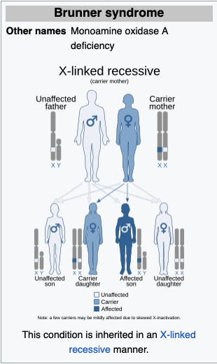

## Adoption Studies

Compares adoptees to biological parents (genetic influence) and adoptive parents (environmental influence).

Genetic predisposition: Higher similarity to bio-parents (e.g., criminal behavior in adoptees correlates with bio-parents’ history).

Environmental factors: Similarity to adoptive family (e.g., parenting style, trauma, socioeconomic status).

Adoptee with criminal behavior linked to bio-parents’ history → genetic risk

Adoptee’s aggression mirrors adoptive siblings exposed to abuse → environmental risk

# Phsysiology, Molecular Genetics, and Criminology

## Autonomic Nervious System

A network of nerves regulating unconscious bodily processes

Helps the body adapt to environmental changes, particularly during danger or stress

Activates the “fight or flight” reaction to prepare the body for immediate action

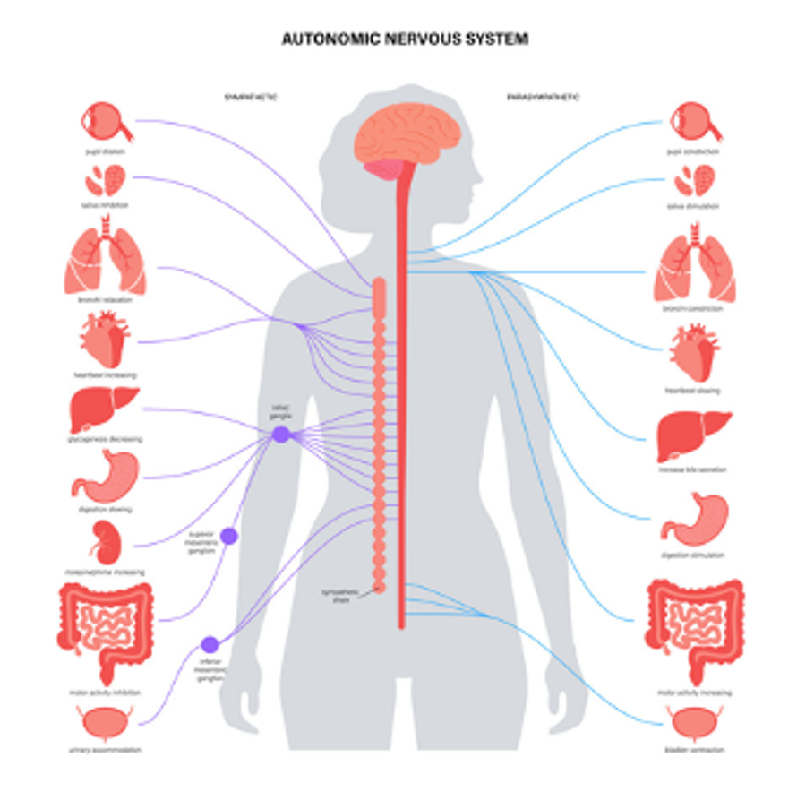

## ANS and Psychopathy

Low Resting Heart Rate Hypothesis:

Associated with increased antisocial behavior.

May reflect reduced fear, facilitating risk-taking and antisocial acts

Low Arousal Hypothesis:

Low ANS arousal may create an unpleasant 🙁 physiological state.

Individuals may engage in stimulating or antisocial behaviors to increase arousal to optimal levels

## Psychopathy

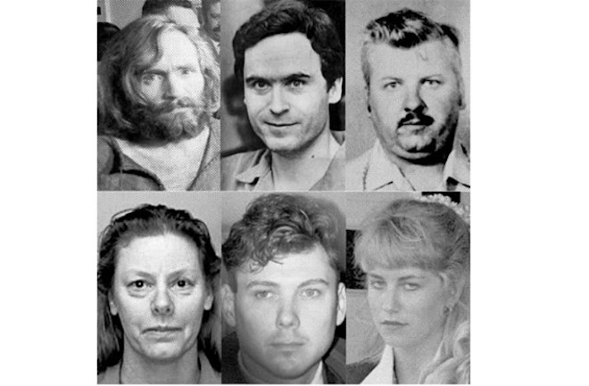

Image: Discovery Magazine

[figure not shown]

image: giphy

## Psychopathy

A type of antisocial behavior characterized by constellation of traits:

Callousness: Lack of empathy or concern for others’ feelings

Unemotionality: Absence of emotional depth or responsiveness

Manipulativeness: Skilled at exploiting others for personal gain

Impulsivity: Acting without forethought or consideration of consequences

Shallow Affect: Superficial or limited emotional expression

## Resting Heart Rate

`01:00`

Check pulse

*Watch the clock (15 seconds or 30 seconds) and count heart beats and multiply by 4 or 2*

Write it down

[figure not shown]

## Survey

`01:00`

[The Inventory of Callous-Unemotional Traits](https://arc.psych.wisc.edu/self-report/the-inventory-of-callous-unemotional-traits-icu/)

Higher scores 🧮 indicate higher Callous-Unemotional Traits!

The ICU has three subscales: Callousness, Uncaring, and Unemotional

Take your survey

## Score and Analyze

What was your heart rate at rest?

What was your score?

[figure not shown]

image: giphy

# If you have a lower heart rate at rest and higher callousness scores chances are…

## Drum Roll

[figure not shown]

image: giphy

# You’re just a hungry college student who wants this class to end so you can go have lunch 🤪

## RECAP

Hand back Exam!

News 🗞️ incoming!!!

- I dropped twin studies from the lecture, won’t be on any quiz or exam! Wooohooo!

## Hormones

Hormones are the body’s chemical messengers that travel through the blood stream (think long range 🚀)

Testosterone

The major sex hormone in males, essential to the development of male growth and masculine characteristics

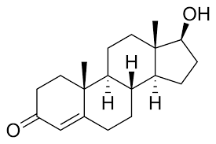

Cortisol

The body’s main stress hormone, involved in the 🤺 or 🛫 response.

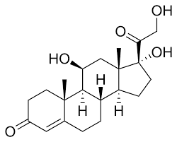

## Hormones and Crime

Testosterone

Linked to aggression, dominance, and risk-taking behaviors, specifically violent and impulsive crimes (e.g., assault).

Cortisol

Low levels tied to reduced fear, poor impulse control, and sensation-seeking.

Interaction Effect

(High testosterone) x (Low cortisol) = aggression and rule-breaking (e.g., “dual hormone hypothesis”).

Here’s a cool paper on the role of [testosterone, cortisol, and criminal behavior in men and women](https://www.sciencedirect.com/science/article/abs/pii/S0018506X22001544).

## Neurotransmitters

Chemical messengers that transmit signals between neurons (think short range 🧠)

Serotonin

Often referred to as the ‘feel-good’ molecule - involved in mood regulation, sleep, appetite, learning, memory, and many other things.

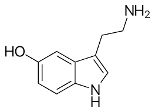

Dopamine

Released during pleasurable activities, essential for motivation, attention, mood, and even physical movement (e.g., Parkinson’s disease is a result degradation of the dopamine producing cells).

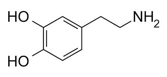

## Neurotransmitters and Crime

Serotonin

Low serotonin levels have been associated depression & anxiety.

Mostly associated with crimes due to mental health incident which can be homicide and/or suicide. Also, drug-related offenses.

[Very famous paper regarding serotonin aka 5HT](https://pubmed.ncbi.nlm.nih.gov/12869766/)

Dopamine

Hyperactivity is associated with addiction, compulsive behaviors, or crimes tied to sensation-seeking.

Associated with antisocial personality disorders (e.g., psychopathy) and impulsive anti-social behavior.

Interaction Effect

(High dopamine) x (Low serotonin) = heightened impulsivity and reward-driven aggression (e.g., “hot-tempered” vs. “cold-tempered” criminal acts)

## Genetics x the Environment (GxE)

All the work showed that it is an interaction between the moleculer genetics and the environment

It’s never just genetics or just the environment. Its both!

And finally, as we’ll see, genetics isn’t always a bad thing.

It really just make peoples more sensitive or more resistant to the environment they are.

## Neurodiversity

The natural variations in brain function that shape how individuals process information, perceive the world, and interact with others. These differences—shaped by evolutionary and developmental influence.

People experience and interact with the world around them in many ways, with no one “right” way of thinking, learning, and behaving, and differences are not deficits.

Read more at [Harvard Health](https://www.health.harvard.edu/blog/what-is-neurodiversity-202111232645).

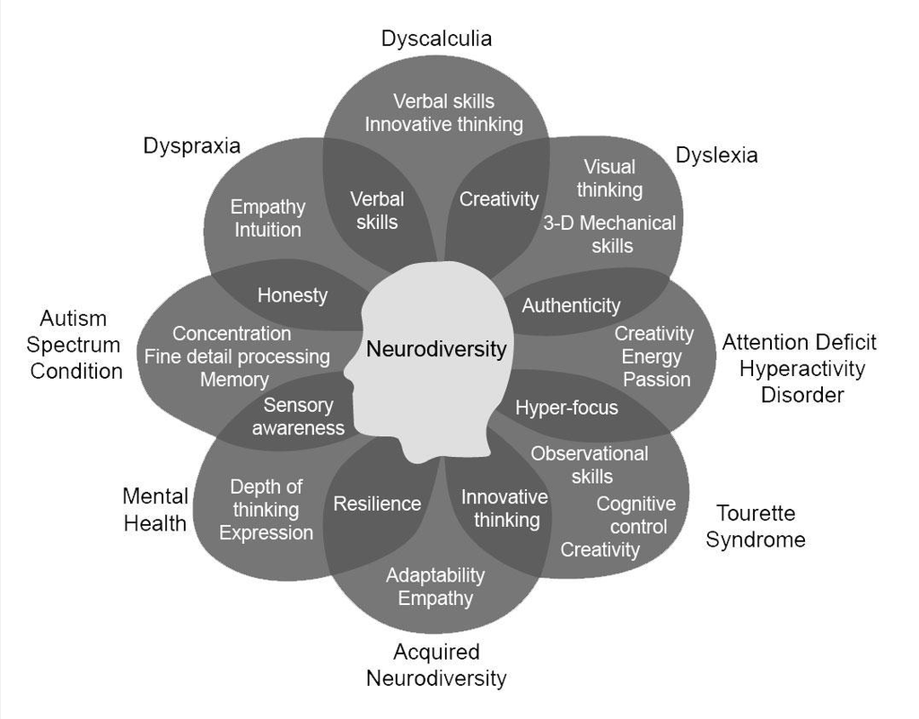

image: National Library of Medicine

## Differential Susceptibility

An evolutionary developmental theory proposing that genetic variation influences environmental sensitivity, shaping neurodiversity

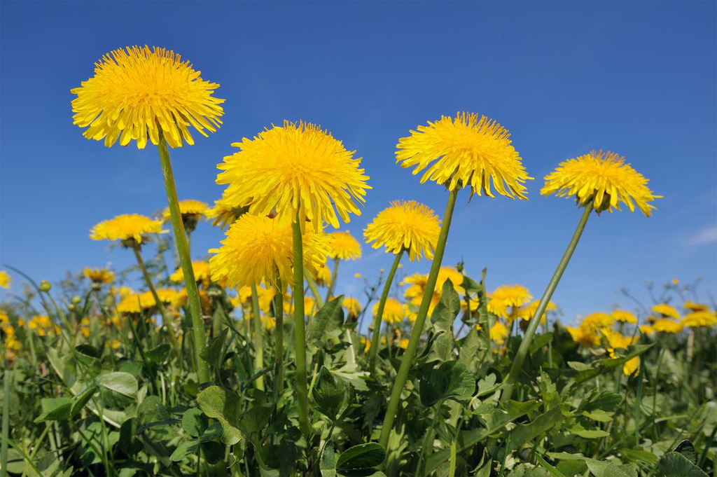

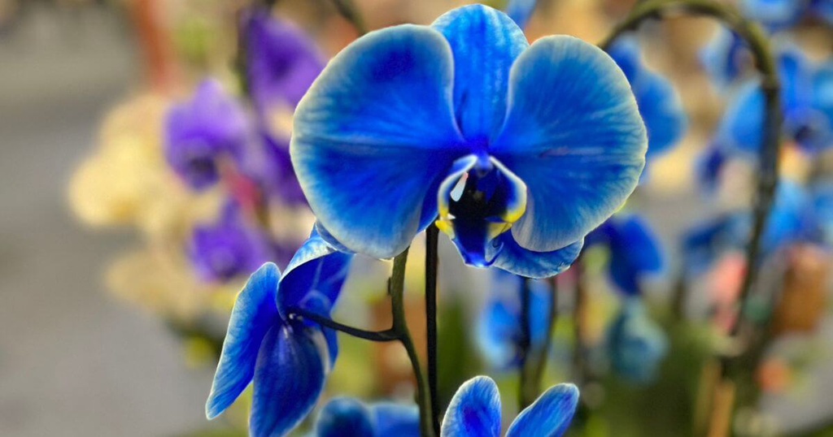

## Sensitivity and Neurodiversity

**‘Dandelion’ Children**

Children who are less reactive to their environments and are not as strongly affected by all experiences, both positive and negative

Can thrive in a wide range of circumstances and more resistant to environmental variation

**‘Orchid’ Children**

Children who are more sensitive to environmental factors and are more affected by all experiences, both positive and negative

Can thrive in optimal circumstance that are less resistant to environmental variation.

*When given optimal circumstance they exceed in the top percentile level*

When not optimal, they may be more susceptible to harsh effects of the environment they are in, and thus can lead to negative behavior outcomes

# Group Discussion!!!!

## Group Discussion

`10:00`

Studies suggest that both psychiatric interventions (e.g., Selective serotonin reuptake inhibitors) and mindfulness-based/holistic approaches can reduce symptoms related to antisocial behavior disorder. Given limited funding, should prison rehabilitation systems prioritize:

A.) Pharmacological interventions (e.g., SSRIs) with social support programs

B.) Holistic interventions (e.g., meditation) with social support programs

Pick one and make an argument for your choice. Elect one speaker to present your point.

## Policy

[Early Intervention Programs](https://pubmed.ncbi.nlm.nih.gov/16770765/)

Evidence-based parenting support: Fund programs to promote sensitive, proactive parenting strategies (e.g., positive discipline, emotional regulation training).

[Nutritional Interventions for Crime Prevention](https://penntoday.upenn.edu/news/time-has-come-implement-omega-3-supplementation-reduce-aggression)

Integrate omega-3 fatty acids (e.g., fish oils) into at-risk youth diets, linked to improved impulse control and reduced aggression in clinical trials.

## Have a Great Break!

[figure not shown]

image: giphy